# The pdp R package

08-10-2020

This report aims to present the capabilities of the package `pdp`.

The document is a part of the paper “Landscape of R packages for eXplainable Machine Learning”, S. Maksymiuk, A. Gosiewska, and P. Biecek. (https://arxiv.org/abs/2009.13248). It contains a real life use-case with a hand of [titanic_imputed](https://modeloriented.github.io/DALEX/reference/titanic.html) data set described in Section *Example gallery for XAI packages* of the article.

We did our best to show the entire range of the implemented explanations. Please note that the examples may be incomplete. If you think something is missing, feel free to make a pull request at the GitHub repository MI2DataLab/XAI-tools.

The list of use-cases for all packages included in the article is [here](http://xai-tools.drwhy.ai/).

The document contains a use-case of on the [titanic_imputed](https://modeloriented.github.io/DALEX/reference/titanic.html) data set described in Section real-world use-case of the article.

We did our best to show the entire range of the implemented explanations. Please note that the examples may be incomplete. If you think something is missing, feel free to make a pull request at the GitHub repository MI2DataLab/IML-tools

The document is a part of the paper “Landscape of R packages for ExplainableMachine Learning”, S. Maksymiuk, A. Gosiewska, and P. Biecek. The list of use-cases for all packages included in the article is [here](https://mi2datalab.github.io/IML-tools/).

Load [`titanic_imputed`](https://modeloriented.github.io/DALEX/reference/titanic.html) data set.

```r
data(titanic_imputed, package = "DALEX")

head(titanic_imputed)
```

```
##   gender age class    embarked  fare sibsp parch survived
## 1   male  42   3rd Southampton  7.11     0     0        0
## 2   male  13   3rd Southampton 20.05     0     2        0
## 3   male  16   3rd Southampton 20.05     1     1        0
## 4 female  39   3rd Southampton 20.05     1     1        1
## 5 female  16   3rd Southampton  7.13     0     0        1
## 6   male  25   3rd Southampton  7.13     0     0        1
```

```r
library(pdp)
library(ggplot2)
library(randomForest)

set.seed(123)
```

Fit a random forest to the titanic imputed data.

```r
rf_model <- randomForest(factor(survived)~., data = titanic_imputed[1:10,])
```

# Model parts

## Variable importance

Extract the most important predictors.

```r
topPredictors(rf_model, n = 3)
```

```
## [1] "age"    "fare"   "gender"
```

# Model profile

## PDP with ICE curves.

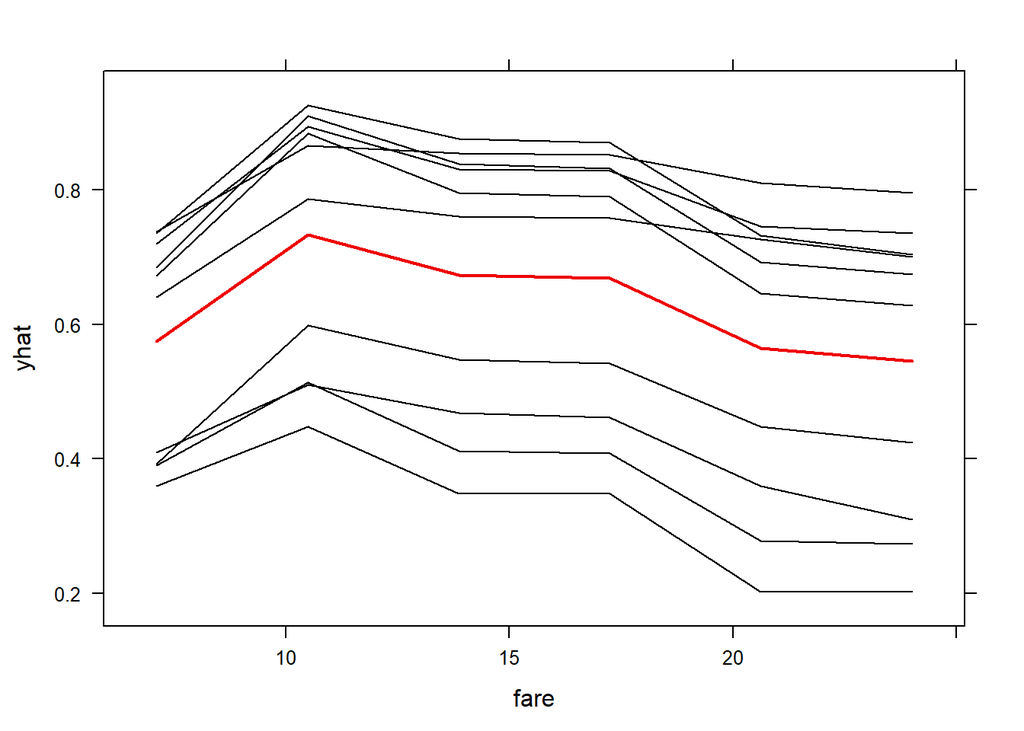

```r
pred_fun <- function(object, newdata) predict(object, newdata, type = "prob")[,2]
rf_pdp <- partial(rf_model, pred.var = c("fare"), ice = TRUE, pred.fun = pred_fun )
plotPartial(rf_pdp)
```

PDP for two variables

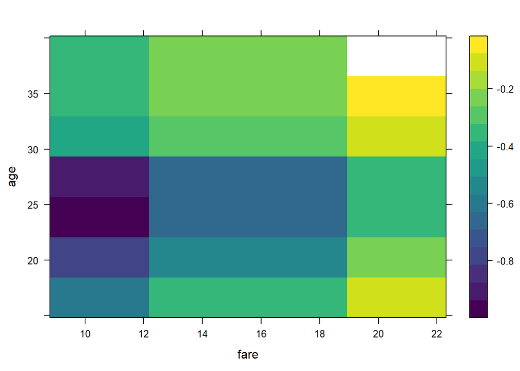

```r
rf_pdp <- partial(rf_model, pred.var = c("fare", "age"), chull = TRUE)
plotPartial(rf_pdp)
```

Use `autoplot` function to produce PDP with `ggplot2`.

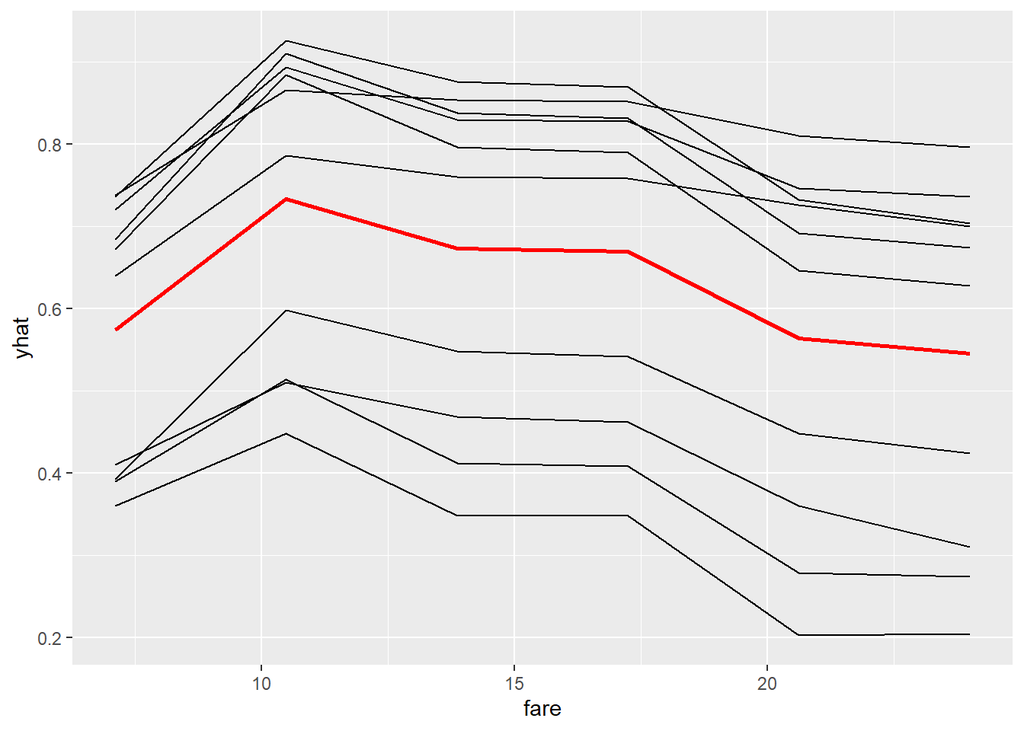

```r
pred_fun <- function(object, newdata) predict(object, newdata, type = "prob")[,2]
rf_pdp <- partial(rf_model, pred.var = c("fare"), ice = TRUE, pred.fun = pred_fun)
autoplot(rf_pdp)
```